# Vignette

Valeria Policastro - Dario Righelli

2019-07-30

# Abstract

In network analysis, many community detection algorithms have been developed. However,their applications leave unaddressed one important question: the statistical validation of the results. Are the detected communities significant or are they a result of chance only due to the positions of edges in the network?

ROBIN (Robustness In Network) is an R package for the Validation of community detection it has a double aim it studies the robustness of a community detection algorithm and compares the robustness of two community algorithms.

The package implements a methodology that detects if the community structure found by a detection algorithm is statistically significant or is a result of chance, merely due to edge positions in the network. It performs a perturbation strategy and runs a null model to build a set of procedures based on different stability measures.

In particular, it provides: 1)A procedure to examine the stability of the partition recovered against random perturbations of the original graph structure 2)Three tests to determine whether the obtained clustering departs significantly from the null model 3)A routine to compare different detection algorithms applied to the same network to discover which fits better 4)A graphical interactive representation

### Install packages

```r
#install.packages("devtools")
library(devtools)
install_github("ValeriaPolicastro/robin",force=TRUE)
```

```
## Skipping 1 packages not available: gprege
```

[output not shown]

```r
library("robin")
library("gprege")
```

# Preparation of the Graph

As input, the **ROBIN** package expects a network that can be read from different format: edgelist, pajek, graphml, gml, ncol, lgl, dimacs, graphdb and igraph graphs.

With the **prepGraph** function we create an *igraph* object, from the selected input file, needed for the ROBIN execution.

```r
my_file <- system.file("example/football.gml", package="robin")
# downloaded from: http://www-personal.umich.edu/~mejn/netdata/
graph <- prepGraph(file=my_file, file.format="gml")
graph
```

```
## IGRAPH 460fc48 U--- 115 613 --
## + attr: id (v/n), label (v/c), value (v/n)
## + edges from 460fc48:
##  [1] 1--  2 1--  5 1-- 10 1-- 17 1-- 24 1-- 34 1-- 36 1-- 42 1-- 66 1-- 91
## [11] 1-- 94 1--105 2-- 26 2-- 28 2-- 34 2-- 38 2-- 46 2-- 58 2-- 90 2--102
## [21] 2--104 2--106 2--110 3--  4 3--  7 3-- 14 3-- 15 3-- 16 3-- 48 3-- 61
## [31] 3-- 65 3-- 73 3-- 75 3--101 3--107 4--  6 4-- 12 4-- 27 4-- 41 4-- 53
## [41] 4-- 59 4-- 73 4-- 75 4-- 82 4-- 85 4--103 5--  6 5-- 10 5-- 17 5-- 24
## [51] 5-- 29 5-- 42 5-- 70 5-- 94 5--105 5--109 6-- 11 6-- 12 6-- 53 6-- 75
## [61] 6-- 82 6-- 85 6-- 91 6-- 98 6-- 99 6--108 7--  8 7-- 33 7-- 40 7-- 48
## [71] 7-- 56 7-- 59 7-- 61 7-- 65 7-- 86 7--101 7--107 8--  9 8-- 22 8-- 23
## + ... omitted several edges
```

# Random Graph

In such a way, we can create the Random graph (null model) that has to be used for the package, the graph argument must be of the same type returned by the **prepGraph** function.

```r
graphRandom <- random(graph=graph)
graphRandom
```

```
## IGRAPH baa1a5a U--- 115 613 --
## + attr: id (v/n), label (v/c), value (v/n)
## + edges from baa1a5a:
##  [1]  1--  2  1--  5  1-- 10  1-- 17  1-- 89  1-- 34  1-- 33 96-- 98
##  [9]  1-- 83  1-- 91  1-- 56  1--105  2-- 89 84--103  2-- 80 38--115
## [17]  2-- 29  2-- 58  2-- 70  2--103 85--109 73--106  2--110  4-- 51
## [25]  3-- 32 14-- 69  3--  7  3-- 88 48--107 61-- 93  3-- 14 84-- 99
## [33]  3-- 68 76--101  3--  6  4--  6  4-- 12 86--109  4-- 41  4-- 53
## [41] 59-- 87  4-- 73  4-- 22 82-- 84  4-- 98  4--103  5--  9  5-- 10
## [49]  5-- 87  5--109  5-- 29  5--108 70-- 81  5-- 94 32-- 79  5--104
## [57]  6-- 11  6-- 40 53-- 97 75-- 78  6-- 82  6-- 85 25-- 86  6-- 71
## + ... omitted several edges
```

# Plot graph

To have a graphical representation of the network we use the **plotGraph** function implemented with aid of *networkD3* package.

```r
plotGraph(graph)
```

[interactive chart not shown]

# Create Community

To create the communities, in the package are implemented all the igraph algorithms.

```r
methodCommunity(graph=graph, method="fastGreedy") #as community
```

```
## IGRAPH clustering fast greedy, groups: 6, mod: 0.55
## + groups:
##   $`1`
##    [1]   7  14  16  33  40  48  61  65 101 107
##
##   $`2`
##    [1]   8   9  10  17  22  23  24  42  47  50  52  54  68  69  74  78  79
##   [18]  89 105 109 111 112 115
##
##   $`3`
##    [1]   1   2  20  26  30  31  34  36  38  46  56  80  81  83  90  94  95
##   [18] 102 104 106 110
##   + ... omitted several groups/vertices
```

```r
membershipCommunities(graph=graph, method="fastGreedy") #as membership
```

```
##   [1] 3 3 5 5 5 5 1 2 2 2 5 5 4 1 4 1 2 6 4 3 6 2 2 2 5 3 4 6 5 3 3 4 1 3 4
##  [36] 3 6 3 4 1 5 2 6 4 6 3 2 1 6 2 5 2 5 2 4 3 6 6 6 6 1 4 6 6 1 6 6 2 2 5
##  [71] 6 4 5 2 5 6 6 2 2 3 3 5 3 5 5 4 6 6 2 3 5 6 6 3 3 6 6 6 5 4 1 3 5 3 2
## [106] 3 1 5 2 3 2 2 6 6 2
```

# Community Plot

It gives an interactive 3D plot of the communites for the chosen algorithm.

```r
members <- membershipCommunities(graph=graph, method="fastGreedy")
plotComm(graph=graph, members=members)
```

[interactive chart not shown]

# Procedure to validate the robustness

It creates the ROBIN procedure to validate the robustness of your network. In this example we used the “vi” distance as a stability measure, the indipendent type of procedure and the louvain algorithm as a community detection algorithm, but users can choose different measures (“nmi”,“split.join”, “adjusted.rand”) and algorithms (walktrap“,”edgeBetweenness“,”fastGreedy“,”spinglass“,”leadingEigen“,”labelProp“,”infomap“,”optimal“,”other“) implemented in the package. To make things easier we save the output list in the *proc* variable because to use it later.

```r
proc <- robinRobust(graph=graph, graphRandom=graphRandom, measure="vi",
                  method="louvain", type="independent")
```

```
## [1] 31
## [1] 61
## [1] 92
## [1] 123
## [1] 153
## [1] 184
## [1] 215
## [1] 245
## [1] 276
## [1] 306
## [1] 337
## [1] 368
```

# Robin Plots

Now in order to compare the obtained curves from the Procedure we can make a plot with the **plotRobin** function. It shows on the y-axis the average of the chosen measure while on the x-axis the percentuage of perturbation of the real data and the null model.

The *model1* and *model2* arguments are, respectively, the *Mean* and the *MeanRandom* contained inside the **robinRobust** output list.

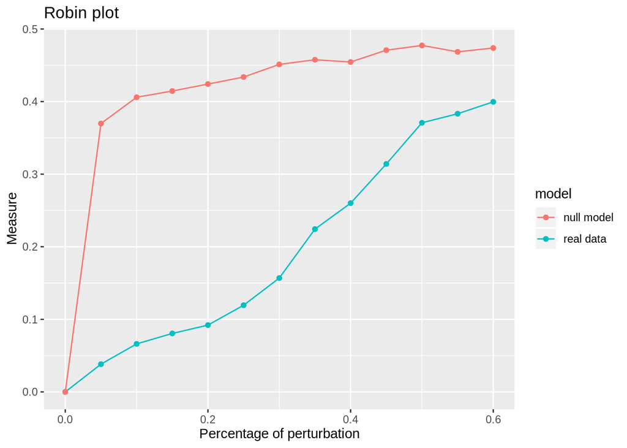

```r
plotRobin(graph=graph, model1=proc$Mean, model2=proc$MeanRandom,
legend=c("real data", "null model"), measure="vi")
```

# Statistical Tests between Real data and Null model

Now we test the differeces between this two curves with: - Functional data analysis - Gaussian Process - Area Under the Curve (AUC) The *model1* and *model2* arguments are, respectively, the *Mean* and the *MeanRandom* contained inside the **robinRobust** output list.

```
## [1] "First step: basis expansion"
## Swapping 'y' and 'argvals', because 'y' is  simpler,
##   and 'argvals' should be;  now  dim(argvals) =  13 ;  dim(y) =  13 x 20
## [1] "Second step: joint univariate tests"
## [1] "Third step: interval-wise combination and correction"
## [1] "creating the p-value matrix: end of row 2 out of 9"
## [1] "creating the p-value matrix: end of row 3 out of 9"
## [1] "creating the p-value matrix: end of row 4 out of 9"
## [1] "creating the p-value matrix: end of row 5 out of 9"
## [1] "creating the p-value matrix: end of row 6 out of 9"
## [1] "creating the p-value matrix: end of row 7 out of 9"
## [1] "creating the p-value matrix: end of row 8 out of 9"
## [1] "creating the p-value matrix: end of row 9 out of 9"
## [1] "Interval Testing Procedure completed"
```

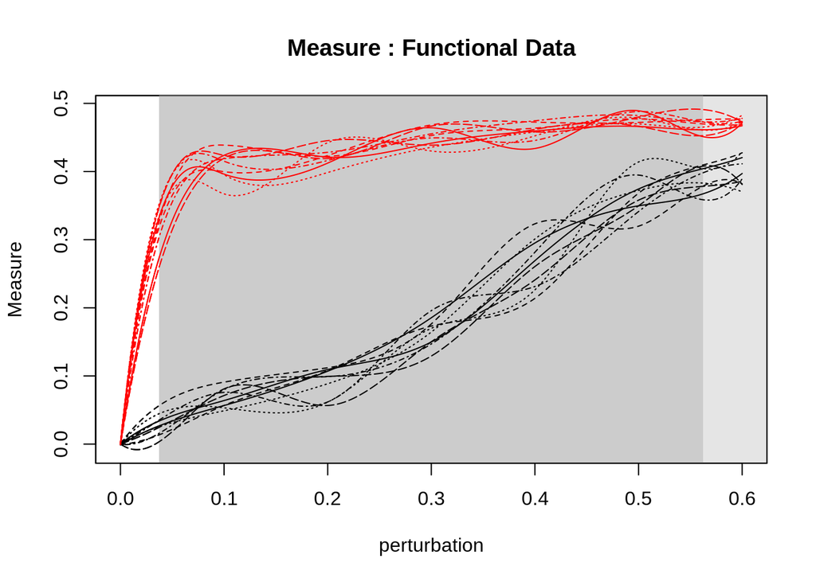

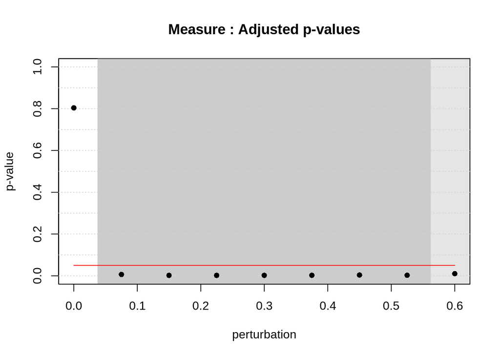

```
## $ask
## [1] TRUE
```

```r
robinFDATest(graph=graph, model1=proc$Mean, model2=proc$MeanRandom,
             measure="vi")
```

```r
robinGPTest(ratio=proc$ratios)
```

```
##  Profile  1
##  Profile  2
```

```
## [1] 128.9449
```

```r
robinAUC(graph=graph, model1=proc$Mean, model2=proc$MeanRandom,
             measure="vi")
```

```
## $area1
## [1] 0.1153625
##
## $area2
## [1] 0.2551312
```

# Comparison Two different Methods

Now we want to see which algorithm (between two of them) better detects the communities. For example if we take the *Fast Greedy* and *Louvain* algorithms, we want to check which one better fits our network. We firstly plot them with their different communities to have an idea of the network of interest.

```r
membersFast <- membershipCommunities(graph=graph, method="fastGreedy")
membersLouv <- membershipCommunities(graph=graph, method="louvain")
plotComm(graph=graph, members=membersFast)
```

[interactive chart not shown]

```r
plotComm(graph=graph, members=membersLouv)
```

[interactive chart not shown]

Secondly, we run the **robinCompare** function to compare the two algorithms, which, as before, we store the output in the *comp* variable to use it later.

```r
comp <- robinCompare(graph=graph, method1="fastGreedy",
                method2="louvain", measure="vi", type="independent")
```

```
## [1] 31
## [1] 61
## [1] 92
## [1] 123
## [1] 153
## [1] 184
## [1] 215
## [1] 245
## [1] 276
## [1] 306
## [1] 337
## [1] 368
```

Thirdly, we plot the two curves of the two methods in comparison. The *model1*, *model2* arguments are, respectively, the *Mean1*, *Mean2* contained inside the **robinCompare** output list.

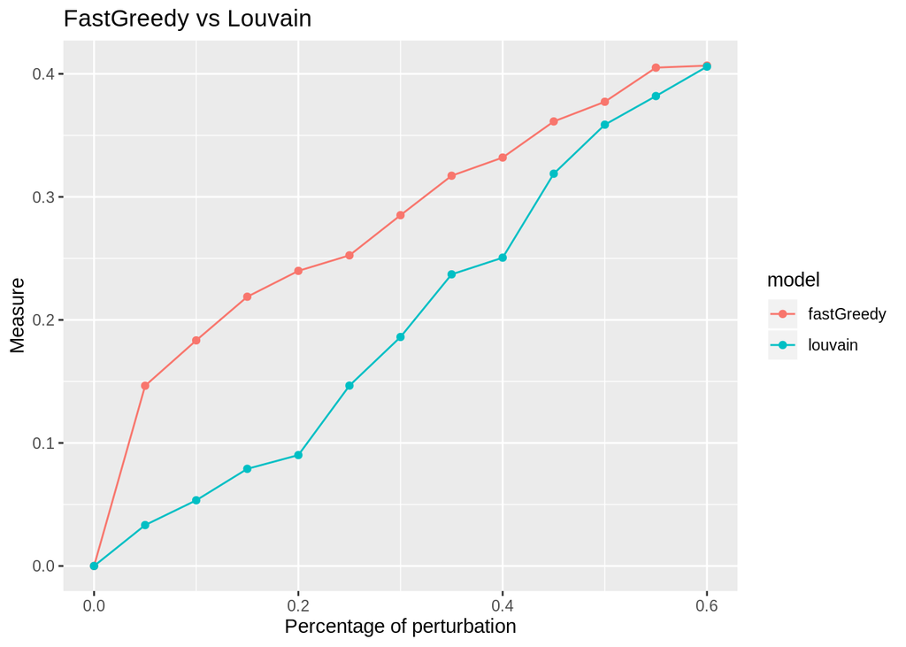

```r
plotRobin(graph=graph, model1=comp$Mean1, model2=comp$Mean2, measure="vi",
legend=c("fastGreedy", "louvain"), title="FastGreedy vs Louvain")
```

# Statistical Tests between two community detection algorithms

Now we test the differeces between the two curves, as we did before but for the comparison of the two different methods the *model1* argument must be the *Mean1* and the *model2* argument must be the *Mean2* both contained inside the **robinCompare** output list.

```
## [1] "First step: basis expansion"
## Swapping 'y' and 'argvals', because 'y' is  simpler,
##   and 'argvals' should be;  now  dim(argvals) =  13 ;  dim(y) =  13 x 20
## [1] "Second step: joint univariate tests"
## [1] "Third step: interval-wise combination and correction"
## [1] "creating the p-value matrix: end of row 2 out of 9"
## [1] "creating the p-value matrix: end of row 3 out of 9"
## [1] "creating the p-value matrix: end of row 4 out of 9"
## [1] "creating the p-value matrix: end of row 5 out of 9"
## [1] "creating the p-value matrix: end of row 6 out of 9"
## [1] "creating the p-value matrix: end of row 7 out of 9"
## [1] "creating the p-value matrix: end of row 8 out of 9"
## [1] "creating the p-value matrix: end of row 9 out of 9"
## [1] "Interval Testing Procedure completed"
```

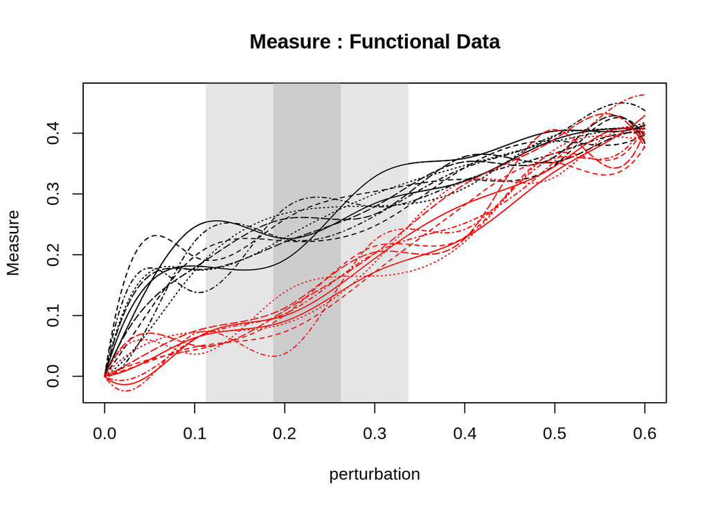

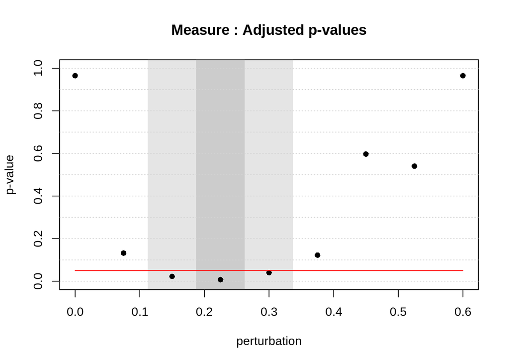

```
## $ask
## [1] TRUE
```

```r
robinFDATest(graph=graph, model1=comp$Mean1, model2=comp$Mean2, measure="vi")
```

```r
robinGPTest(ratio=comp$ratios1vs2)
```

```
##  Profile  1
##  Profile  2
```

```
## [1] 24.4271
```

```r
robinAUC(graph=graph, model1=comp$Mean1, model2=comp$Mean2, measure="vi")
```

```
## $area1
## [1] 0.1668817
##
## $area2
## [1] 0.1169842
```